# R Notebook

```r
library(tidyverse)
load('namcs08.RData')
```

1)What proportion of people in the patients data frame are taking an alternative medicine (based on the “level1” variable in the drugclasses data frame)?

```r
#prop=number/sum(number))
left_join(drugclasses,left_join(distinct(drugs),patients))%>%filter(level1=="Alternative medicines") %>% group_by(id)%>%summarize(n=n())%>%mutate(alt_num=if_else(n >= 1 ,1,0))%>%summarize(num=sum(alt_num))%>% mutate(prop=num/nrow(patients))
```

| num | prop |
| --- | --- |
| 653 | 0.02272016 |

2)How many medications are taken on average (mean and median) by all individuals in the patients data frame?

```r
left_join(patients,distinct(drugs))%>%mutate(drug=if_else(is.na(drug),0,1))%>%group_by(id) %>% summarize(n=sum(drug))%>%summarize(mean=mean(n),median=median(n))
```

| mean | median |
| --- | --- |
| 2.318465 | 2 |

3. What is the most common medication (or drug) for each of the conditions listed in the pmh data frame? Look up the drug that is most commonly taken for depression in the drugclasses data frame. Based on the description of the drug, is this expected or surprising that this is the most commonly taken drug in depression?

```r
grouped=pmh%>%gather(diagnosis,status,2:15) %>%filter(status==1)
left_join(drugclasses,left_join(distinct(drugs),grouped))%>%group_by(diagnosis,drug)%>%summarize(num=n())%>%arrange(desc(num))%>%slice(1)
```

| diagnosis | drug | num |
| --- | --- | --- |
| arthritis | ASPIRIN | 288 |
| asthma | ALBUTEROL | 510 |
| cancer | ASPIRIN | 159 |
| cerebvascdz | ASPIRIN | 114 |
| chf | FUROSEMIDE | 154 |
| copd | ALBUTEROL | 177 |
| crf | FUROSEMIDE | 69 |
| depression | SERTRALINE | 226 |
| diabetes | METFORMIN | 680 |
| htn | ASPIRIN | 1179 |

[output cut: 5 more lines]

```r
grouped=pmh%>%gather(diagnosis,status,2:15) %>%filter(status==1)
left_join(drugclasses,left_join(distinct(drugs),grouped))%>%filter(diagnosis=="depression") %>% group_by(diagnosis,drug)%>%summarize(num=n())%>%arrange(desc(num))%>%slice(1)
```

| diagnosis | drug | num |
| --- | --- | --- |
| depression | SERTRALINE | 226 |

the most common drug used for depression is SERTRALINE.

```r
drugclasses %>% filter(drug=="SERTRALINE")
```

| drug | level1 | level2 | level3 |
| --- | --- | --- | --- |
| SERTRALINE | Psychotherapeutic agents | Psychotherapeutic agents; antidepressants | Psychotherapeutic agents; antidepressants; SSRI antidepressants |

No, its not surprising that sertraline is the most commonly used drug for depression as it falls under the category of anti-depressants according to its description.

4. What is the distribution of body temperature for individuals in the dataset? Would you describe this distribution as “normal” or skewed?

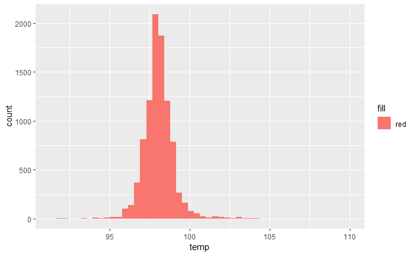

```r
patients%>%ggplot(aes(temp,fill="red"))+geom_histogram(bins = 50)
```

the distribution of body temperatures is in between 95-103 and is fairly symmetrical so I would describe this as a normal distribution.

5. Is body temperature different in men versus women? Which statistical test would you use to evaluate this association?

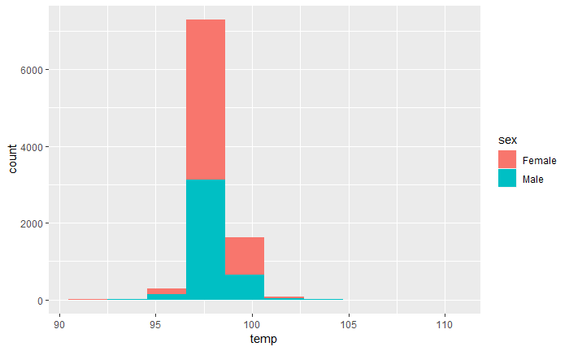

```r
patients%>%mutate(sex=if_else(sex=="Male",'Male','Female'))%>%ggplot(aes(x=temp,fill=sex))+geom_histogram(bins=10)
```

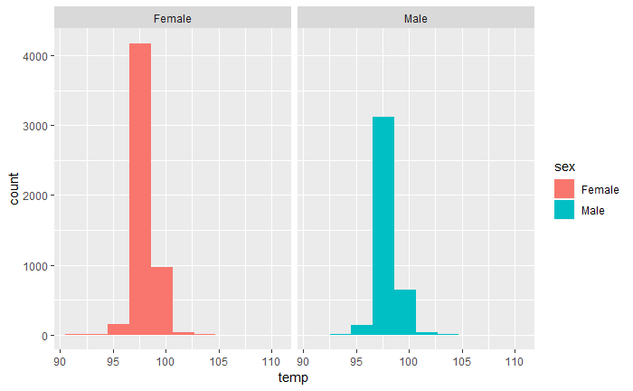

```r
patients%>%mutate(sex=if_else(sex=="Male",'Male','Female'))%>%ggplot(aes(x=temp,fill=sex))+geom_histogram(bins=10)+facet_wrap(~sex)
```

The graphs above show that the temperatures in both genders are overlapping which means that the body temperatures are not differnt in men vs women. its the same.I would use one sample t-test for comparison.

6. Is congestive heart failure (chf) more common in patients with chronic renal failure (crf) as compared to individuals without chronic renal failure? Use the pmh data frame. Which statistical test would you use to evaluate the association between CHF and CRF?

Note: Before you plot, you should use mutate() to convert the chf column into a character variable with values of “CHF” and “No CHF” (for values 1 and 0, respectively) and convert the crf column into a character variable with values of “CRF” and “No CRF”.

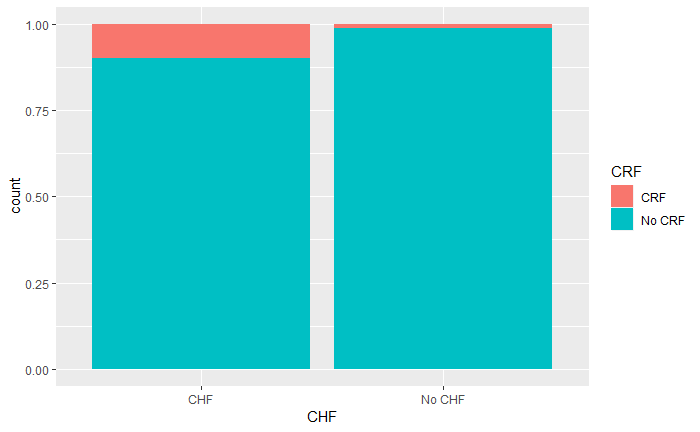

```r
pmh%>%mutate(CHF=if_else(chf==1,'CHF','No CHF'), CRF= if_else(crf==1,'CRF' ,'No CRF'))%>%ggplot(aes(x=CHF,fill=CRF))+geom_bar(position='fill')
```

YES, congestive heart failure (chf) is more common in patients with chronic renal failure (crf) as compared to individuals without chronic renal failure. I would use two sample test to find the association between crf and chf.

7. Demonstrate the relationship between systolic and diastolic blood pressure. Use a scatterplot and add a best-fit line (not a curve). Which statistical test would you use to evaluate the association between systolic and diastolic blood pressure?

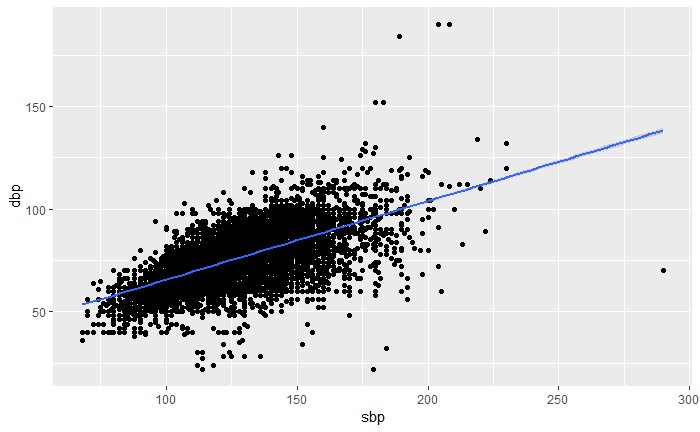

```r
patients %>%
ggplot(aes(x = sbp, y = dbp)) +
geom_point()+geom_smooth(method=lm)
```

I WOULD USE a 2-sample t-test for comparison.

8. Is the relationship between systolic and diastolic blood pressure different for individuals with congestive heart failure (chf = 1 in the pmh data frame) as compared to those without congestive heart failure?

Note: Before you plot, you should use mutate() to convert the chf column into a character variable with values of “CHF” and “No CHF” (for values 1 and 0, respectively)

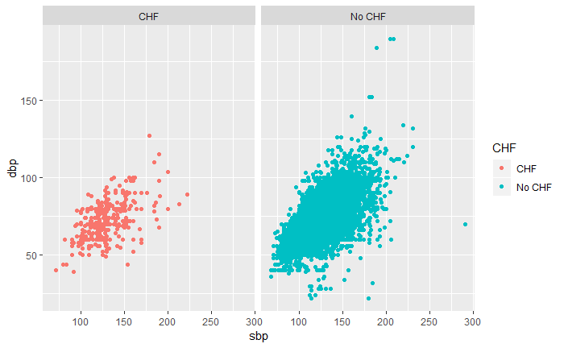

```r
left_join(patients,pmh)%>%mutate(CHF=if_else(chf==1,'CHF','No CHF'))%>%ggplot(aes(x=sbp,y=dbp, color=CHF))+geom_point()+facet_wrap(~CHF)
```

No, The relationship between the two groups is the same.